# hw4

yang an

2024-12-24

## question

###answer: Homework 4

####1. # (a)

```
##      [,1]
## [1,]    1
## [2,]    1
## [3,]    1
## [4,]    1
## [5,]    1
## [6,]    1
## [7,]    1
## [8,]    1
```

# (b)

```
##      [,1] [,2]
## [1,]    1    0
## [2,]    1    0
## [3,]    1    0
## [4,]    1    0
## [5,]    1    1
## [6,]    1    1
## [7,]    1    1
## [8,]    1    1
```

# (c)

```
##        times
## [1,] 1     8
## [2,] 1    10
## [3,] 1    12
## [4,] 1    14
## [5,] 1     8
## [6,] 1    10
## [7,] 1    12
## [8,] 1    14
```

# (d)

```
##        times
## [1,] 1     8 0
## [2,] 1    10 0
## [3,] 1    12 0
## [4,] 1    14 0
## [5,] 1     8 1
## [6,] 1    10 1
## [7,] 1    12 1
## [8,] 1    14 1
```

# (e)

```
##        times
## [1,] 1     8 0
## [2,] 1    10 0
## [3,] 1    12 0
## [4,] 1     8 1
## [5,] 1    10 1
## [6,] 1    12 1
```

# (f)

```
##        times
## [1,] 1     8 0  64 0
## [2,] 1    10 0 100 0
## [3,] 1    12 0 144 0
## [4,] 1     8 1  64 1
## [5,] 1    10 1 100 1
## [6,] 1    12 1 144 1
```

# (g)

We can use the same quadratic time trend as the baseline model, compare it with alternative models, and evaluate the significance of any improvement in fit and alignment with the data.

#####(h)

```
## Linear mixed model fit by REML ['lmerMod']
## Formula: distance ~ 1 + (1 | id)
##    Data: dental_data
##
## REML criterion at convergence: 515.4
##
## Scaled residuals:
##     Min      1Q  Median      3Q     Max
## -3.2400 -0.5277 -0.1073  0.4732  2.7687
##
## Random effects:
##  Groups   Name        Variance Std.Dev.
##  id       (Intercept) 3.752    1.937
##  Residual             4.930    2.220
## Number of obs: 108, groups:  id, 27
##
## Fixed effects:
##             Estimate Std. Error t value
## (Intercept)  24.0231     0.4297   55.91
```

```
## Linear mixed model fit by REML ['lmerMod']
## Formula: distance ~ gender + (1 | id)
##    Data: dental_data
##
## REML criterion at convergence: 505.9
##
## Scaled residuals:
##     Min      1Q  Median      3Q     Max
## -3.3709 -0.5111 -0.0640  0.4893  2.6690
##
## Random effects:
##  Groups   Name        Variance Std.Dev.
##  id       (Intercept) 2.547    1.596
##  Residual             4.930    2.220
## Number of obs: 108, groups:  id, 27
##
## Fixed effects:
##             Estimate Std. Error t value
## (Intercept)  24.9687     0.4860  51.376
## genderGirl   -2.3210     0.7614  -3.048
##
## Correlation of Fixed Effects:
##            (Intr)
## genderGirl -0.638
```

```
## Linear mixed model fit by REML ['lmerMod']
## Formula: distance ~ age + (1 | id)
##    Data: dental_data
##
## REML criterion at convergence: 447
##
## Scaled residuals:
##     Min      1Q  Median      3Q     Max
## -3.6645 -0.5351 -0.0129  0.4874  3.7218
##
## Random effects:
##  Groups   Name        Variance Std.Dev.
##  id       (Intercept) 4.472    2.115
##  Residual             2.049    1.432
## Number of obs: 108, groups:  id, 27
##
## Fixed effects:
##             Estimate Std. Error t value
## (Intercept) 16.76111    0.80240   20.89
## age          0.66019    0.06161   10.72
##
## Correlation of Fixed Effects:
##     (Intr)
## age -0.845
```

```
## Linear mixed model fit by REML ['lmerMod']
## Formula: distance ~ age * gender + (1 | id)
##    Data: dental_data
##
## REML criterion at convergence: 433.8
##
## Scaled residuals:
##     Min      1Q  Median      3Q     Max
## -3.5980 -0.4546  0.0158  0.5024  3.6862
##
## Random effects:
##  Groups   Name        Variance Std.Dev.
##  id       (Intercept) 3.299    1.816
##  Residual             1.922    1.386
## Number of obs: 108, groups:  id, 27
##
## Fixed effects:
##                Estimate Std. Error t value
## (Intercept)     16.3406     0.9813  16.652
## age              0.7844     0.0775  10.121
## genderGirl       1.0321     1.5374   0.671
## age:genderGirl  -0.3048     0.1214  -2.511
##
## Correlation of Fixed Effects:
##             (Intr) age    gndrGr
## age         -0.869
## genderGirl  -0.638  0.555
## age:gndrGrl  0.555 -0.638 -0.869
```

#####(i) 1.(Intercept) (Estimate = 16.3406): This is the estimated starting value (baseline distance) for males when age is 0. The average distance for males is 16.34 mm when age equal to 0.

2.age (Estimate = 0.7844):

This represents the average increase in distance per year of age for males (the reference gender). The distance increases by 0.784 mm per year for males.

3.genderGirl (Estimate = 1.0321):

This is the estimated difference in the baseline distance between females and males when age is 0. Females is 1.032 mm greater than males when age is 0.

4.age:genderGirl (Estimate = -0.3048): This is the interaction term between age and gender (specifically for females), representing the difference in the slope of age for females compared to males. The slope of age for females is 0.3048 mm less than that for males. Females have a slightly lower slope of 0.784−0.3048≈0.479 mm per year while males have a slope of approximately 0.784 mm per year.

Summary of Fixed Effects Baseline (age 0): Males start at an average distance of 16.34 mm, while females start at a slightly higher distance of 17.37 mm (16.34 + 1.032). Time trend (slope): Males increase by 0.784 mm per year, while females increase by approximately 0.479 mm per year, indicating a smaller rate of increase in distance for females. ####2. #####(a)

```
##      [,1] [,2] [,3] [,4] [,5]
## [1,]    1    0    0    0    0
## [2,]    1    1    0    0    0
## [3,]    1    1    1    0    0
## [4,]    1    1    1    1    0
## [5,]    1    1    1    1    1
```

#####(b)

```
##      [,1] [,2] [,3] [,4] [,5]
## [1,]    1    0    0    0    0
## [2,]    0    1    0    0    0
## [3,]    0    0    1    0    0
## [4,]    0    0    0    1    0
## [5,]    0    0    0    0    1
```

#####(c) Five columns in both parts. #####(d) In the first parametrization, each 𝛼𝑘represents the cumulative mean up to the k-th time. In the second, each 𝛼𝑘represents the mean for the k-th time point directly.

####3. #####(a) Fit each model separately. Report the fixed effects (regression output) results for all

```
##                        Model                Term    Estimate  Std_Error
## ...1                Model 1a         (Intercept) 24.02314815 0.42966048
## (Intercept)...2     Model 1b         (Intercept) 24.96875000 0.48600076
## genderGirl...3      Model 1b          genderGirl -2.32102273 0.76141686
## (Intercept)...4     Model 1c         (Intercept) 17.70671296 0.83392247
## genderGirl...5      Model 1c          genderGirl -2.32102273 0.76141685
## age...6             Model 1c                 age  0.66018519 0.06160592
## (Intercept)...7     Model 1d         (Intercept) 16.34062500 0.98131224
## age...8             Model 1d                 age  0.78437500 0.07750110
## genderGirl...9      Model 1d          genderGirl  1.03210227 1.53742081
## age:genderGirl...10 Model 1d      age:genderGirl -0.30482955 0.12142090
## (Intercept)...11    Model 1f         (Intercept) 22.23125000 5.14103793
## age...12            Model 1f                 age -0.33281250 0.96014521
## genderGirl...13     Model 1f          genderGirl -5.18806818 8.05445849
## I(age^2)            Model 1f            I(age^2)  0.05078125 0.04349940
## age:genderGirl...15 Model 1f      age:genderGirl  0.87485795 1.50425845
## genderGirl:I(age^2) Model 1f genderGirl:I(age^2) -0.05362216 0.06815046
##                        t_value
## ...1                55.9119330
## (Intercept)...2     51.3759481
## genderGirl...3      -3.0482944
## (Intercept)...4     21.2330445
## genderGirl...5      -3.0482944
## age...6             10.7162627
## (Intercept)...7     16.6518101
## age...8             10.1208235
## genderGirl...9       0.6713206
## age:genderGirl...10 -2.5105197
## (Intercept)...11     4.3242727
## age...12            -0.3466273
## genderGirl...13     -0.6441238
## I(age^2)             1.1674011
## age:genderGirl...15  0.5815875
## genderGirl:I(age^2) -0.7868202
```

#####(b)

```
## [1] 521.3618 513.8718 447.5125 445.7572 456.8836
```

```
## [1] 4
```

```
##                   Model           Term   Estimate Std_Error    t_value
## (Intercept)    Model 1d    (Intercept) 16.3406250 0.9813122 16.6518101
## age            Model 1d            age  0.7843750 0.0775011 10.1208235
## genderGirl     Model 1d     genderGirl  1.0321023 1.5374208  0.6713206
## age:genderGirl Model 1d age:genderGirl -0.3048295 0.1214209 -2.5105197
```

```
## refitting model(s) with ML (instead of REML)
```

```
## Data: dental_data
## Models:
## model_1c: distance ~ gender + age + (1 | id)
## model_1d: distance ~ age * gender + (1 | id)
##          npar    AIC    BIC  logLik deviance  Chisq Df Pr(>Chisq)
## model_1c    5 444.86 458.27 -217.43   434.86
## model_1d    6 440.64 456.73 -214.32   428.64 6.2174  1    0.01265 *
## ---
## Signif. codes:  0 '***' 0.001 '**' 0.01 '*' 0.05 '.' 0.1 ' ' 1
```

####4. Draw an inference plot. Estimate the average response and its standard error for the boys and the girls at each time point and plot over time. Explain the difference between this inference plot and the empirical summary plot you drew for homework 3.

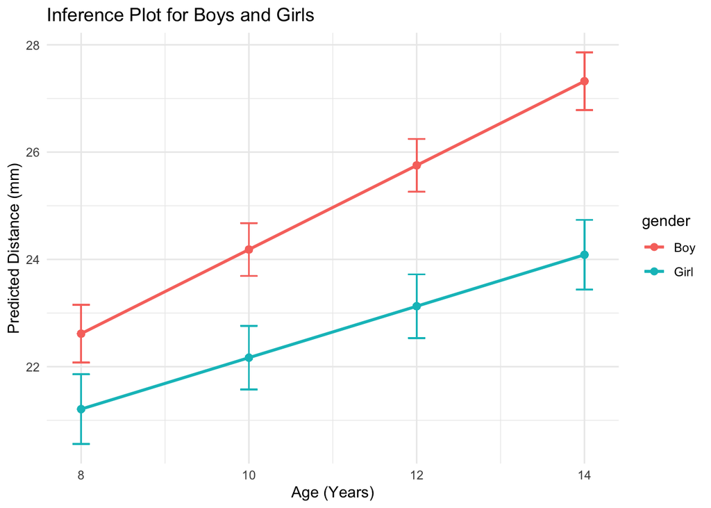

Both plots show the relationship between age and distance, but the inference plot includes the standard error of the predicted values, the confidence intervals is smaller than the empirical summary plot. The epirical summary plot shows the raw data points and the average distance at each time point, without any model assumptions, while the inference plot shows the predicted average distance with confidence intervals based on the model.

####5. #####(a) The most complicated fixed effect model is one that includes all possible interactions： gender and age, gender and quadratic age. In addtion, the model also would include the gender effects, time trend, and the quadratic time trend. #####(b) Fit the most complicated model:

```
## Linear mixed model fit by REML ['lmerMod']
## Formula: distance ~ age + gender + I(age^2) + age:gender + I(age^2):gender +
##     (1 | id)
##    Data: dental_data
##
## REML criterion at convergence: 440.9
##
## Scaled residuals:
##     Min      1Q  Median      3Q     Max
## -3.7300 -0.5003  0.0297  0.4542  3.8174
##
## Random effects:
##  Groups   Name        Variance Std.Dev.
##  id       (Intercept) 3.295    1.815
##  Residual             1.938    1.392
## Number of obs: 108, groups:  id, 27
##
## Fixed effects:
##                     Estimate Std. Error t value
## (Intercept)         22.23125    5.14104   4.324
## age                 -0.33281    0.96015  -0.347
## genderGirl          -5.18807    8.05446  -0.644
## I(age^2)             0.05078    0.04350   1.167
## age:genderGirl       0.87486    1.50426   0.582
## genderGirl:I(age^2) -0.05362    0.06815  -0.787
##
## Correlation of Fixed Effects:
##             (Intr) age    gndrGr I(g^2) ag:gnG
## age         -0.992
## genderGirl  -0.638  0.633
## I(age^2)     0.982 -0.997 -0.626
## age:gndrGrl  0.633 -0.638 -0.992  0.636
## gndrG:I(^2) -0.626  0.636  0.982 -0.638 -0.997
```

```
## refitting model(s) with ML (instead of REML)
```

```
## Data: dental_data
## Models:
## model_1d: distance ~ age * gender + (1 | id)
## model_complex: distance ~ age + gender + I(age^2) + age:gender + I(age^2):gender + (1 | id)
##               npar    AIC    BIC  logLik deviance  Chisq Df Pr(>Chisq)
## model_1d         6 440.64 456.73 -214.32   428.64
## model_complex    8 443.21 464.67 -213.61   427.21 1.4241  2     0.4906
```

The P-value is 0.4906>0.05, we cannot reject the h0 and conclude that there is no significant impact to improve the model by adding the quadratic terms. Therefore, the simpler model is sufficient and should be preferred over the more complex model.